# Homework 11

Adrian Wiegman

April 4, 2018

### 1. Examine a function useful to your research

I am examining the Langmuir Equation:

$$S = \frac{S_{max}kC}{1+kC} + S_0$$

This model which describes the relation between $S$ (mg kg<sup>-1</sup>), the quantity of phosphorus sorbed to soil and $C$ (mg L<sup>-1</sup>), the concentration of dissolved phosphorus in soil porewater. The model assumes there is a limited capacity of the soils to adsorb sediment resulting in a maximum quantity of sorbed soil phosphorus, $S_{max}$ (mg kg<sup>-1</sup>). $S_{min}$ is the amount of P sorbed to the soil at when $C$ is neglibable The physical soil properties (such as grain size) and biogeochemical regulators (such as pH, eH, tempurature, and OM) affect $S_{max}$ and $S_{min}$; The concentration Al and Fe in soil is a very strong predictor of $S_{max}$. $k$ (L mg<sup>-1</sup>), is a coefficient that describes the energy of adsorbtion, which has low variability and is often assumed constant (Reddy & DeLaune 2011; Reddy et al. 1999).

```r
#########################################################
# FUNCTION: Langmuir
# half saturation equation for sediment P concentration
# as a function of dissolved P concentration determined
# during sorption isotherm experiments with soil cores.
# INPUT: C - (mg L^-1) concentration of dissolve P in soil porewater
#        k - (L mg^-1) adsorption energy coefficient
#        Sm - (mg kg^-1) maximum soil p concentration
#        So - (mg kg^-1) minimum soil p concentration
# OUTPUT: S - vector
#-------------------------------------------------------
Langmuir <- function(C=NULL,
                     k=0.5,
                     Sm=1,
                     So=0.01){
  if (is.null(C)) C <- c(0.02,
                         0.04*1.9^1:10,
                         seq(0.01,10,length.out=5))
  S <- (Sm*k*C)/(1+k*C) + So
return(S)
}
Langmuir()
```

```
##  [1] 0.01990099 0.04660886 0.06482042 0.08235622 0.09925319 0.11554562
##  [7] 0.13126538 0.14644214 0.16110357 0.17527546 0.01497512 0.56629506
## [13] 0.72448965 0.79952907 0.84333333
```

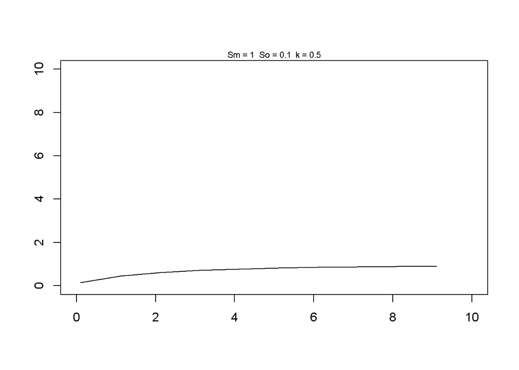

```r
###################################################
# FUNCTION: LangmuirPlot
# half saturation equation for sediment P concentration
# as a function of dissolved P concentration determined
# during sorption isotherm experiments with soil cores.
# INPUT: C - (mg L^-1) concentration of dissolve P in soil porewater
#        k - (L mg^-1) adsorption energy coefficient
#        Sm - (mg kg^-1) maximum soil p concentration
#        So - (mg kg^-1) minimum soil p concentration
# OUTPUT: ggplot of langmuir equation
#-------------------------------------------------
LangmuirPlot <- function(C=NULL,
                         k=0.5,
                         Sm=1,
                         So=0.1,
                         Labels=FALSE,
                         xnum='t',
                         ynum='t'){
  if (is.null(C)) C <- 0.1:10
  if (Labels==TRUE){
    lb <- c("S - Sorbed P (mg/kg)",
           "C - Dissolved P Conc. (mg/L)")
    a <- TRUE
    }else{
             lb <- c(NULL,NULL)
             a <- FALSE

           }
  S<-Langmuir(C,k,Sm,So)
  plot(x=C,y=S,type="l",
       ylim=c(0,10),xlim=c(0,10),
       xlab=lb[2],ylab=lb[1],
       ann=a,yaxt = ynum, xaxt = xnum)
  mtext(paste("Sm =", Sm," So =",So," k =",k),cex=0.7)
}
LangmuirPlot()
```

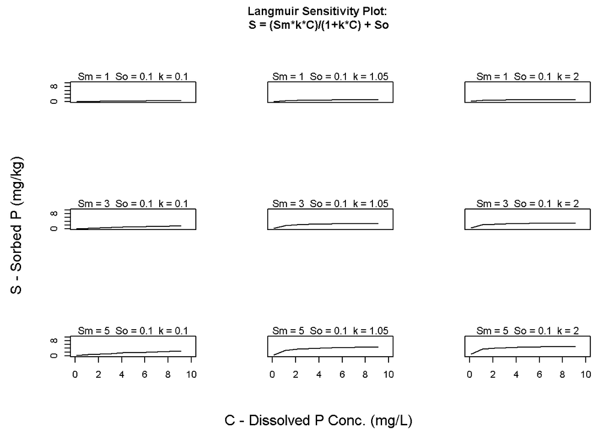

```r
#pdf("arrayplot_HW11.pdf") # open pdf, comment out for knit
# loop to make plot matrix
n <- 3 # number
# set up plot array with title margin 'oma' and set the title to outer.
par(mfrow=c(n,n),oma=c(2,2,3,0))
i = 0
for (Sm in seq(1,5,length.out = n)){
  i = i + 1
  j = 0
  for (k in seq(0.1,2,length.out = n)){
    j = j + 1
    # call lagmuir plot and remove axis labels of inner matrix
    LangmuirPlot(k=k,Sm=Sm,Labels=FALSE,
                 ynum=(if(j==1)'t'else'n'),# remove inner y axis values
                 xnum=(if(i==3)'t'else'n'))# remove inner x axis values
  }
}
title(main="Langmuir Sensitivity Plot: \n S = (Sm*k*C)/(1+k*C) + So ",outer=TRUE)
mtext("S - Sorbed P (mg/kg)",side=2,outer=TRUE) # Y axis
mtext("C - Dissolved P Conc. (mg/L)",side=1,outer=TRUE) # X axis
```

```r
# save plot to pdf

#dev.off() # close pdf, comment out for knit
```

### 2. Conduct a randomization test for some of your own data and ensure the test is repeatable by setting the randomization seed

For this exercise I will use data from laboratory extraction of phosphorus `Y` using two different methods (`X2=A` and `X2=B`) verses Total Phosphorus (`X1`), and I will compare the slopes of the phosphorus extracted phosphorus from method A and method B. I am testing the null hypthosis that difference in slopes is equal to zero. This is a small sample size, n=6 for each method. So assumptions of normality with respect to Y and repect to model residuals may be vialated. Therefore a randomization test or nonparametric approach may be better suited to test the null hypothesis. Results are plotted below.

```r
# get metric
##############################################
# get.pctdiff.slopes
# returns percent difference in regression slopes
# from two x,y dataframes being compared
get.pctdiff.slopes <- function (z=NULL){
  if (is.null(z)){
   z <- data.frame(Y=runif(10),
                     X1=1:10,
                     X2=rep(c('A','B'),5))
  }
  # Y = b0 + b1*X1 + b2*X2B + b3*X1*X2B
  . <- lm(Y~X1*X2,z)
  # slope of x2 A
  s1 <-.$coefficients[2]
  # slope of x2 B
  s2 <-.$coefficients[4] + s1
  pds <- (s2-s1)/s1
  #pds <- abs(s2-s1) diff gives same result P value as pct diff
  return(pds)
}
get.pctdiff.slopes()
```

```
##    X1:X2B
## -2.350734
```

```r
######################################################
# FUNCTION: shuffleData
# randomize the position of x and y values
# input: 3+ colunm data frame for regression (ID, yVar, xVar, x etc..)
# output: 3+ column data frame
#----------------------------------------------------------
shuffleData <- function(z=NULL){
  if(is.null(z)){
    xVar <- 1:20
    yVar <- xVar + 10*rnorm(20)
    z <- data.frame(ID=seq_along(xVar),yVar,xVar)
  }
  z[,2] <- sample(z[,2])
  z[,3] <- sample(z[,3])
  return(z)
}
shuffleData()
```

```
##    ID      yVar xVar
## 1   1 17.779738   11
## 2   2  6.847917   10
## 3   3 -1.723536   17
## 4   4 15.944562    2
## 5   5 11.276090   12
## 6   6 12.910014    5
## 7   7  1.953216    4
## 8   8  5.827253   20
## 9   9 30.503911    3
## 10 10 14.600210   16
## 11 11  1.562407    1
## 12 12 25.228026    6
## 13 13  9.163602   19
## 14 14 19.441861   14
## 15 15  4.170297    8
## 16 16 -5.853022    7
## 17 17 -6.594214   18
## 18 18 14.102507    9
## 19 19 16.990444   13
## 20 20 31.556137   15
```

```r
###########################################################
# FUNCTION: getPVal
# calculate p value for observed, simulated data
# input: list containing observed metric and vector of simulated data
# output: lower, upper tail probability
#----------------------------------------------------------
getPVal <- function(z=NULL){
  if(is.null(z)){
    z <- list(xObs=runif(1),xSim=runif(1000))
  } #end if
  pLower <- mean(z[[2]]<=z[[1]]) #the mean of a boolean vector returns proportion true
  pUpper <- mean(z[[2]]>=z[[1]])
  return(c(pL=pLower,pU=pUpper))
}
getPVal()
```

```
##    pL    pU
## 0.326 0.674
```

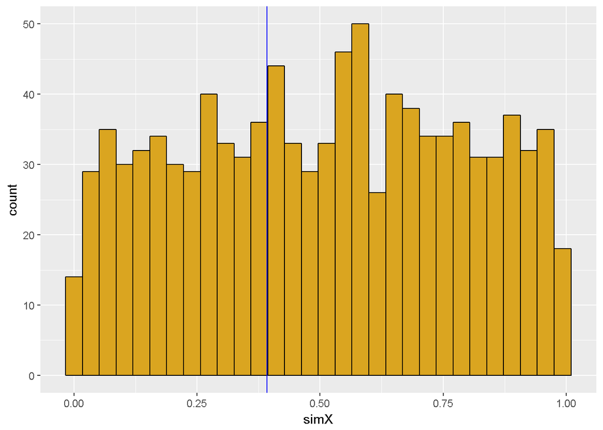

```r
###########################################################
# FUNCTION: plotRanTest
# ggplot graph
# input: list containing observed metric and vector of simulated metrix
# output: ggplot graph
#----------------------------------------------------------
plotRanTest<- function(z=NULL){
  require(ggplot2)
  if(is.null(z)){
    z <- list(xObs=runif(1),xSim=runif(1000))
  } #end if
  df <- data.frame(ID=seq_along(z[[2]]),simX=z[[2]])
  p1 <- ggplot(data=df,mapping=aes(x=simX))
  p1 + geom_histogram(mapping=aes(fill=I("goldenrod"),color=I("black"))) + geom_vline(aes(xintercept=z[[1]],col="blue"))
}
plotRanTest()
```

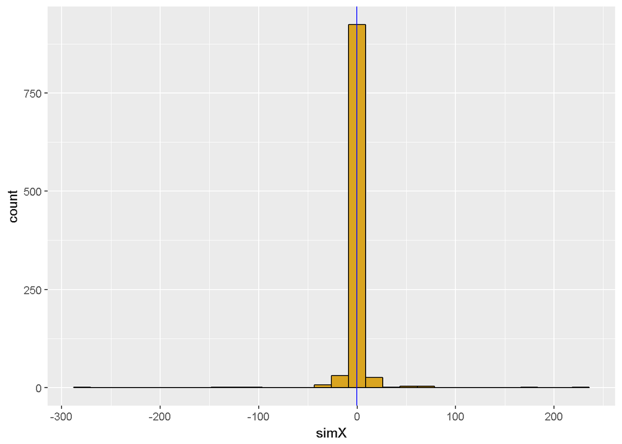

```r
# MAIN PROGRAM----------------------------------
set.seed(10235)
#global variables
nSim <- 1000
Xsim <- rep(NA,nSim) # will hold simulated slopes

# Raw Data in 'wide' format
YA <- c(1659,649,650,377,1825,1924)
YB <- c(965,1855,1972,493,2081,1439)
#YC <- c(3172,6090,5888,4348,13874,9348)
X <- c(4900,6800,6700,5700,13700,10500)
ID <- seq_along(X)
# Convert data into 'long' format
X1 <- rep(X,2)
X2 <- c(rep("A",6),rep("B",6))
Y <- c(YA,YB)
# Make data frame with 'long' format data
df <- data.frame(ID=ID,Y=Y,X1=X1,X2=X2)

# randomization test siginificance of model parameter
Xobs <- get.pctdiff.slopes(df)

for (i in seq_len(nSim)){
  Xsim[i] <- get.pctdiff.slopes(shuffleData(df))
}

slopes <- list(Xobs,Xsim)

test1 <- getPVal(slopes)
plotRanTest(slopes)
```